# Practical Machine Learning - Prediction Assignment Writeup

Annette Spithoven

27-10-2019

## Introduction

This document is the final report of the Peer Assessment project from Coursera’s course Practical Machine Learning, as part of the Specialization in Data Science. It was built up in RStudio, using its knitr functions, meant to be published in html format. The report describes how the model was build, how cross validation was used, and why choices were made as they were.

The main goal of the project is to predict the manner in which 6 participants performed some exercise, as described in the “classe” variable (see explanation below).In order to do so, data from accelerometers on the belt, forearm, arm, and dumbell of 6 participants doing some exercises was used.

### Background

Devices such as Jawbone Up, Nike FuelBand, and Fitbit make it possible to collect a large amount of data about personal activity relatively inexpensively. These type of devices are part of the quantified self movement – a group of enthusiasts who take measurements about themselves regularly to improve their health, to find patterns in their behavior, or because they are tech geeks. One thing that people regularly do is quantify how much of a particular activity they do, but they rarely quantify how well they do it. [The training data for this project are available here.](https://d396qusza40orc.cloudfront.net/predmachlearn/pml-training.csv) [The test data are available here.](https://d396qusza40orc.cloudfront.net/predmachlearn/pml-testing.csv)

## Experiment Setup

Six young health participants were asked to perform one set of 10 repetitions of the Unilateral Dumbbell Biceps Curl in five different fashions:

- exactly according to the specification (Class A)
- throwing the elbows to the front (Class B)
- lifting the dumbbell only halfway (Class C)
- lowering the dumbbell only halfway (Class D)
- throwing the hips to the front (Class E).

Class A corresponds to the specified execution of the exercise, while the other 4 classes correspond to common mistakes. Participants were supervised by an experienced weight lifter to make sure the execution complied to the manner they were supposed to simulate. The exercises were performed by six male participants aged between 20-28 years, with little weight lifting experience. It was made sure that all participants could easily simulate the mistakes in a safe and controlled manner by using a relatively light dumbbell (1.25kg) [^1].

## Getting and Cleaning the Data

We load the data directly from the site.

```r
## Create vector with the URL to the data so that is can be easily loaded
url_trian <- "http://d396qusza40orc.cloudfront.net/predmachlearn/pml-training.csv"
url_test <- "http://d396qusza40orc.cloudfront.net/predmachlearn/pml-testing.csv"

## Loading the data while simultanuously Converting all blank(‘“”’), ‘#DIV/0’ and ‘NA’ values to ‘NA’.
training_data <- read.csv(url(url_trian), na.strings=c("NA","#DIV/0!", ""))
testing_data  <- read.csv(url(url_test), na.strings=c("NA","#DIV/0!", ""))
dim(training_data)
```

```
## [1] 19622   160
```

The data will be partitioned into a training set (70% of the training data) and a test set (30% of the training data) for cross validation purposes. With the dimensions of the trainings data given below.

```r
## Setting seed so that the results are reproducable
set.seed(12345)

## Use 70% of the data for training purposes, other data is used as test
inTrain <- createDataPartition(training_data$classe, p=0.70, list=F)
train_data <- training_data[inTrain, ]
test_data <- training_data[-inTrain, ]
dim(train_data)
```

```
## [1] 13737   160
```

Dimension of the test data

```r
dim(test_data)
```

```
## [1] 5885  160
```

A brief overview of the avialable data (as indicated by their column name).

```r
colnames(train_data)
```

```
##   [1] "X"                        "user_name"
##   [3] "raw_timestamp_part_1"     "raw_timestamp_part_2"
##   [5] "cvtd_timestamp"           "new_window"
##   [7] "num_window"               "roll_belt"
##   [9] "pitch_belt"               "yaw_belt"
##  [11] "total_accel_belt"         "kurtosis_roll_belt"
##  [13] "kurtosis_picth_belt"      "kurtosis_yaw_belt"
##  [15] "skewness_roll_belt"       "skewness_roll_belt.1"
##  [17] "skewness_yaw_belt"        "max_roll_belt"
##  [19] "max_picth_belt"           "max_yaw_belt"
##  [21] "min_roll_belt"            "min_pitch_belt"
##  [23] "min_yaw_belt"             "amplitude_roll_belt"
##  [25] "amplitude_pitch_belt"     "amplitude_yaw_belt"
##  [27] "var_total_accel_belt"     "avg_roll_belt"
##  [29] "stddev_roll_belt"         "var_roll_belt"
```

[output cut: 65 more lines]

To get an idea of what is in the data, and more importantly of how complete the information is, a plot was made with the missings and observed data.

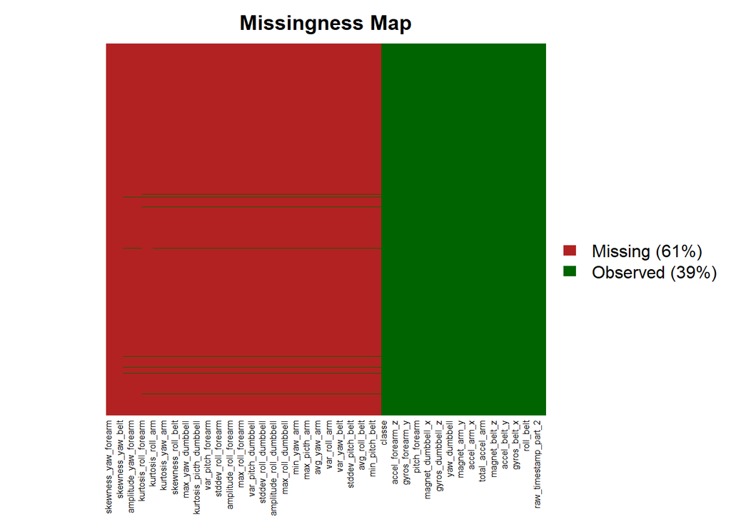

```r
missmap(train_data,
        ## remove y
        y.labels = NULL,
        y.at = NULL,
        ## make text smaller
        x.cex = 0.5,
        ## use better colors than default
        col=c("firebrick", "darkgreen"))
```

```r
## The function takes a column as an argument, it checks the NAs in the column (with the is.na), summarises this and devides it by the total number of observations (with the mean).  lapply is used to apply the function to every column. The columns that have less than 5% missing are saved in a "named logical"
complete_var <- lapply(train_data, function(x) mean(is.na(x))) <= 0.95

## Using the named logical to select the columns with less than 5% missing
train_data <- train_data[ , complete_var == TRUE ]
dim(train_data)
```

```
## [1] 13737    60
```

As some of the variables do not appear to be meaningfull for our model, we will remove them as well.

```r
train_data <- train_data %>%
  select(-c(1:5))
```

Now that the missing data has been removed we will examine the data in somewhat more detail. Lets examine the outcome first.

```r
 table(train_data$classe)
```

```
##
##    A    B    C    D    E
## 3906 2658 2396 2252 2525
```

In order to get an even understanding of the data and the relations between the variables (excluding some non-numeric and the outcome variables), a correlation plot is presented. The darker the color in this plot, the stronger the correlation.

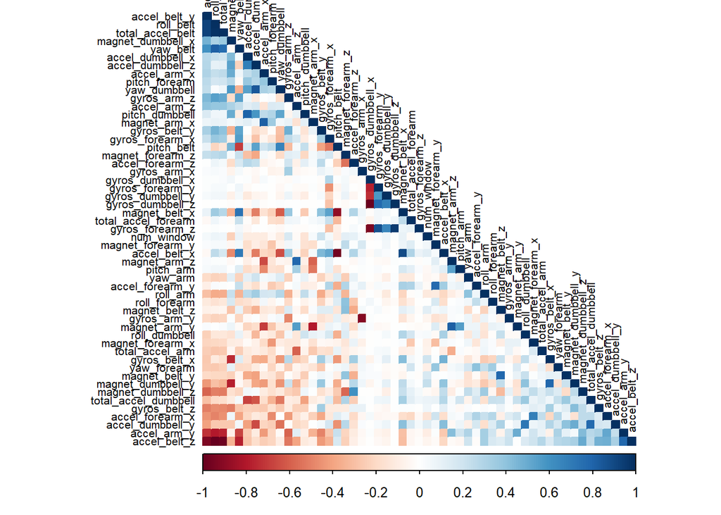

```r
cor_data_train <- cor(train_data[, which(!colnames(train_data) %in% c("classe","new_window"))])
corrplot(cor_data_train,
         order = "FPC",
         method = "color",
         type = "lower",
         tl.cex = 0.65,
         tl.col = rgb(0, 0, 0))
```

## Data Modeling

A decision tree and a random forest are used to predict the data. The best model is than selected to predict the test dataset. It is expected that the random forest performs better than the decision tree.

### Method: Decision Trees

```r
set.seed(12345)
decision_tree <- train(classe ~ ., data=train_data, method="rpart")
decision_tree
```

```
## CART
##
## 13737 samples
##    54 predictor
##     5 classes: 'A', 'B', 'C', 'D', 'E'
##
## No pre-processing
## Resampling: Bootstrapped (25 reps)
## Summary of sample sizes: 13737, 13737, 13737, 13737, 13737, 13737, ...
## Resampling results across tuning parameters:
##
##   cp          Accuracy   Kappa
##   0.03839894  0.5459164  0.41360357
##   0.06092971  0.4038307  0.18597295
##   0.11595972  0.3406163  0.08456319
##
## Accuracy was used to select the optimal model using the largest value.
## The final value used for the model was cp = 0.03839894.
```

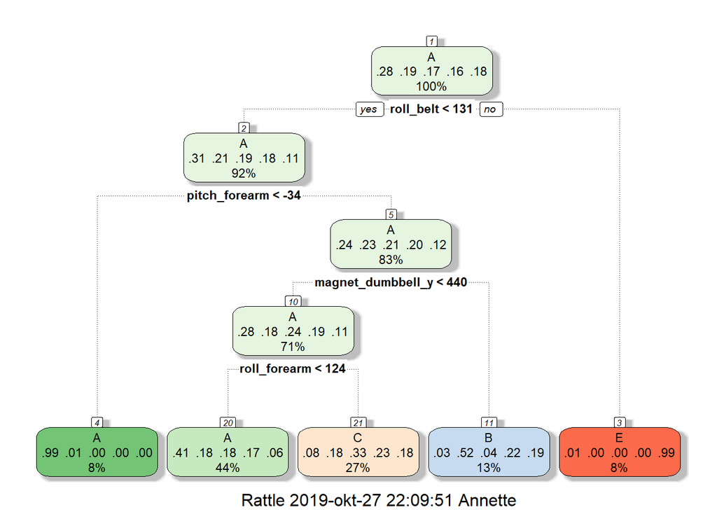

```r
fancyRpartPlot(decision_tree$finalModel)
```

```r
predict_decision_tree <- predict(decision_tree, newdata=test_data)
conf_Mat_decision_tree <- confusionMatrix(predict_decision_tree, test_data$classe)
conf_Mat_decision_tree
```

```
## Confusion Matrix and Statistics
##
##           Reference
## Prediction    A    B    C    D    E
##          A 1525  484  499  423  153
##          B   29  385   37  187  159
##          C  116  270  490  354  289
##          D    0    0    0    0    0
##          E    4    0    0    0  481
##
## Overall Statistics
##
##                Accuracy : 0.4895
##                  95% CI : (0.4767, 0.5024)
##     No Information Rate : 0.2845
##     P-Value [Acc > NIR] : < 2.2e-16
##
##                   Kappa : 0.3324
##
##  Mcnemar's Test P-Value : NA
##
## Statistics by Class:
##
##                      Class: A Class: B Class: C Class: D Class: E
## Sensitivity            0.9110  0.33802  0.47758   0.0000  0.44455
## Specificity            0.6298  0.91319  0.78823   1.0000  0.99917
## Pos Pred Value         0.4945  0.48306  0.32258      NaN  0.99175
## Neg Pred Value         0.9468  0.85181  0.87723   0.8362  0.88870
## Prevalence             0.2845  0.19354  0.17434   0.1638  0.18386
## Detection Rate         0.2591  0.06542  0.08326   0.0000  0.08173
## Detection Prevalence   0.5240  0.13543  0.25811   0.0000  0.08241
## Balanced Accuracy      0.7704  0.62560  0.63291   0.5000  0.72186
```

### Method: Random Forest

```r
set.seed(12345)
control_RF <- trainControl(method="cv", number=3, verboseIter=FALSE)

RF <-  train(classe ~ ., data = train_data,
                 method = "rf",
                 prox = TRUE,
                trControl = control_RF,
             ntree = 10)
RF
```

```
## Random Forest
##
## 13737 samples
##    54 predictor
##     5 classes: 'A', 'B', 'C', 'D', 'E'
##
## No pre-processing
## Resampling: Cross-Validated (3 fold)
## Summary of sample sizes: 9157, 9158, 9159
## Resampling results across tuning parameters:
##
##   mtry  Accuracy   Kappa
##    2    0.9756135  0.9691415
##   28    0.9917009  0.9895002
##   54    0.9904636  0.9879370
##
## Accuracy was used to select the optimal model using the largest value.
## The final value used for the model was mtry = 28.
```

```r
predict_RF <- predict(RF, newdata=test_data)
conf_Mat_RF <- confusionMatrix(predict_RF, test_data$classe)
conf_Mat_RF
```

```
## Confusion Matrix and Statistics
##
##           Reference
## Prediction    A    B    C    D    E
##          A 1674    1    0    1    0
##          B    0 1138    5    0    1
##          C    0    0 1021    6    0
##          D    0    0    0  956    0
##          E    0    0    0    1 1081
##
## Overall Statistics
##
##                Accuracy : 0.9975
##                  95% CI : (0.9958, 0.9986)
##     No Information Rate : 0.2845
##     P-Value [Acc > NIR] : < 2.2e-16
##
##                   Kappa : 0.9968
##
##  Mcnemar's Test P-Value : NA
##
## Statistics by Class:
##
##                      Class: A Class: B Class: C Class: D Class: E
## Sensitivity            1.0000   0.9991   0.9951   0.9917   0.9991
## Specificity            0.9995   0.9987   0.9988   1.0000   0.9998
## Pos Pred Value         0.9988   0.9948   0.9942   1.0000   0.9991
## Neg Pred Value         1.0000   0.9998   0.9990   0.9984   0.9998
## Prevalence             0.2845   0.1935   0.1743   0.1638   0.1839
## Detection Rate         0.2845   0.1934   0.1735   0.1624   0.1837
## Detection Prevalence   0.2848   0.1944   0.1745   0.1624   0.1839
## Balanced Accuracy      0.9998   0.9989   0.9969   0.9959   0.9994
```

## Applying the Best Model to the Test Data.

The accuracy of the models was * Decision Tree: 0.4895 * Random Forest: 0.9975

Therefore, the random forest was used to predict the 20 quiz results (test dataset) as shown below.

```r
set.seed(12345)
predict <- predict(RF, newdata=testing_data)
predict
```

```
##  [1] B A B A A E D B A A B C B A E E A B B B
## Levels: A B C D E
```

## References

[^1]: Ugulino, W.; Cardador, D.; Vega, K.; Velloso, E.; Milidiu, R.; Fuks, H. Wearable Computing: Accelerometers’ Data Classification of Body Postures and Movements. Proceedings of 21st Brazilian Symposium on Artificial Intelligence. Advances in Artificial Intelligence - SBIA 2012. In: Lecture Notes in Computer Science. , pp. 52-61. DOI: 10.1007/978-3-642-34459-6_6.